# Dissertation Participant 3

## Demographic Information

Participant Demographics

| Sex | Age | Prior Concussions | History of Depression or Anxiety |
| --- | --- | --- | --- |
| Female | 13 | 3 | Yes |

## Outcome Measurements

### GAS Hierarchy - Increase weekly assignment completion

| Level | Outcome |
| --- | --- |
| Much more than expected | Complete 80 to 100% of weekly assignments |
| More than expected | Complete 60 to 79% of weekly assginments |
| Expected | Complete 40 to 59% of weekly assignments |
| Baseline | Complete 20 to 39% of weekly assignments |
| Decline | Complete 0 to 19% of weekly assignments |

### BRIEF-2

Elevated scores from the parent-report pre-baseline included:

- Inhibit Scale
- Self-Monitor Scale
- Behavior Regulation Index
- Shift Scale
- Emotional Control Scale
- Emotional Regulation Index
- Initiate Scale
- Working Memory Scale
- Plan/Organize Scale
- Cognitive Regulation Index
- Global Executive Composite

#### BRIEF-2 Self-Report Plot

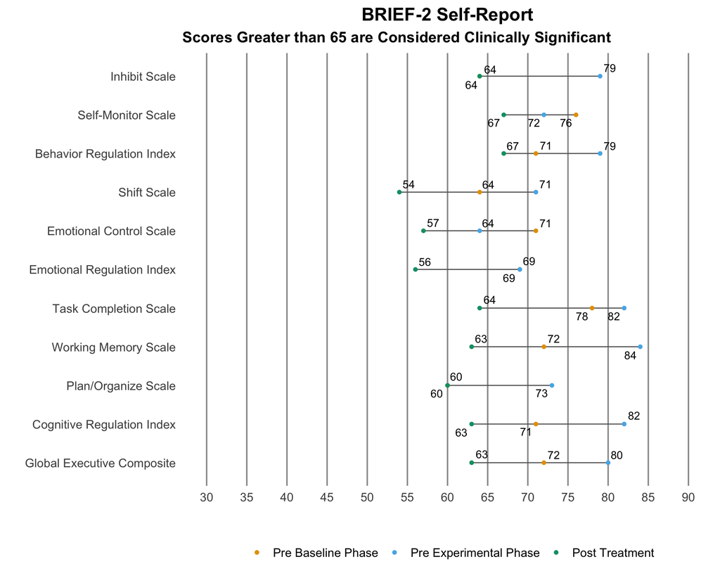

#### BRIEF-2 Self-Report Table Version 1

| Scale/Index | Pre Baseline Phase | Pre Experimental Phase | Post Treatment |
| --- | --- | --- | --- |
| Inhibit Scale | 64 | 79 | 64 |
| Self-Monitor Scale | 76 | 72 | 67 |
| Behavior Regulation Index | 71 | 79 | 67 |
| Shift Scale | 64 | 71 | 54 |
| Emotional Control Scale | 71 | 64 | 57 |
| Emotional Regulation Index | 69 | 69 | 56 |
| Task Completion Scale | 78 | 82 | 64 |
| Working Memory Scale | 72 | 84 | 63 |
| Plan/Organize Scale | 60 | 73 | 60 |
| Cognitive Regulation Index | 71 | 82 | 63 |

[output cut: 1 more lines]

#### BRIEF-2 Self-Report Table Version 2

| Scale/Index | Pre Baseline Phase | Pre Experimental Phase | Post Treatment |
| --- | --- | --- | --- |
| Inhibit Scale | 64 | 79 | 64 |
| Self-Monitor Scale | 76 | 72 | 67 |
| Behavior Regulation Index | 71 | 79 | 67 |
| Shift Scale | 64 | 71 | 54 |
| Emotional Control Scale | 71 | 64 | 57 |
| Emotional Regulation Index | 69 | 69 | 56 |
| Task Completion Scale | 78 | 82 | 64 |
| Working Memory Scale | 72 | 84 | 63 |
| Plan/Organize Scale | 60 | 73 | 60 |
| Cognitive Regulation Index | 71 | 82 | 63 |

[output cut: 1 more lines]

#### BRIEF-2 Parent-Report Plot

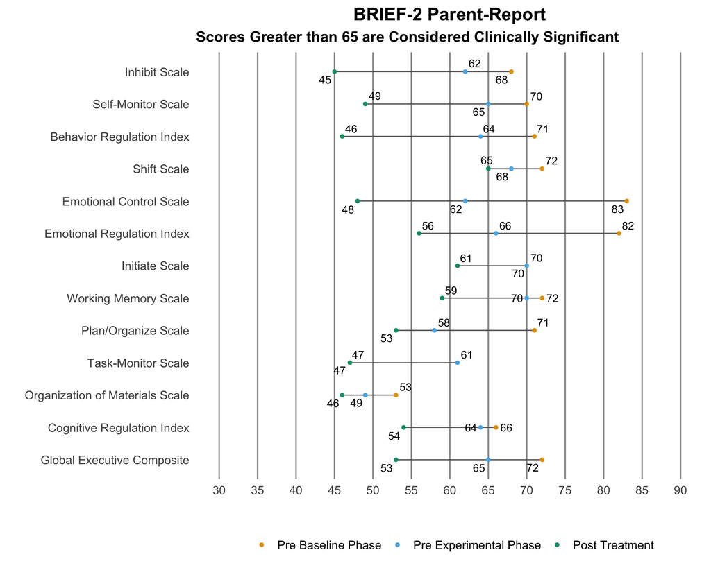

#### BRIEF-2 Parent-Report Table Version 1

| Scale/Index | Pre Baseline Phase | Pre Experimental Phase | Post Treatment |
| --- | --- | --- | --- |
| Inhibit Scale | 68 | 62 | 45 |
| Self-Monitor Scale | 70 | 65 | 49 |
| Behavior Regulation Index | 71 | 64 | 46 |
| Shift Scale | 72 | 68 | 65 |
| Emotional Control Scale | 83 | 62 | 48 |
| Emotional Regulation Index | 82 | 66 | 56 |
| Initiate Scale | 70 | 70 | 61 |
| Working Memory Scale | 72 | 70 | 59 |
| Plan/Organize Scale | 71 | 58 | 53 |
| Task-Monitor Scale | 47 | 61 | 47 |

[output cut: 3 more lines]

#### BRIEF-2 Parent-Report Table Version 2

| Scale/Index | Pre Baseline Phase | Pre Experimental Phase | Post Treatment |
| --- | --- | --- | --- |
| Inhibit Scale | 68 | 62 | 45 |
| Self-Monitor Scale | 70 | 65 | 49 |
| Behavior Regulation Index | 71 | 64 | 46 |
| Shift Scale | 72 | 68 | 65 |
| Emotional Control Scale | 83 | 62 | 48 |
| Emotional Regulation Index | 82 | 66 | 56 |
| Initiate Scale | 70 | 70 | 61 |
| Working Memory Scale | 72 | 70 | 59 |
| Plan/Organize Scale | 71 | 58 | 53 |
| Task-Monitor Scale | 47 | 61 | 47 |

[output cut: 3 more lines]

### CLASS

Self-report responses that guided treatment at time of pre-baseline data collection:

- Easily distracted during homework
- Homework taking longer

Parent-report responses that guided treatment at time of pre-baseline data collection:

- Homework taking longer

#### CLASS Self 1

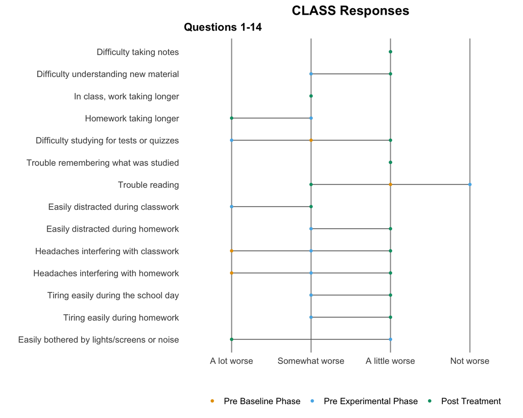

#### CLASS Self 2

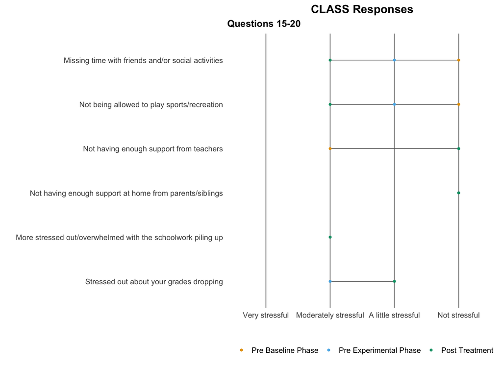

#### CLASS Self Table

| Question | Pre Baseline Phase | Pre Experimental Phase | Post Treatment |
| --- | --- | --- | --- |
| Difficulty taking notes | A little worse | A little worse | A little worse |
| Difficulty understanding new material | Somewhat worse | Somewhat worse | A little worse |
| In class, work taking longer | Somewhat worse | Somewhat worse | Somewhat worse |
| Homework taking longer | Somewhat worse | Somewhat worse | A lot worse |
| Difficulty studying for tests or quizzes | Somewhat worse | A lot worse | A little worse |
| Trouble remembering what was studied | A little worse | A little worse | A little worse |
| Trouble reading | A little worse | Not worse | Somewhat worse |
| Easily distracted during classwork | A lot worse | A lot worse | Somewhat worse |
| Easily distracted during homework | Somewhat worse | Somewhat worse | A little worse |
| Headaches interfering with classwork | A lot worse | Somewhat worse | A little worse |

[output cut: 10 more lines]

#### CLASS Parent 1

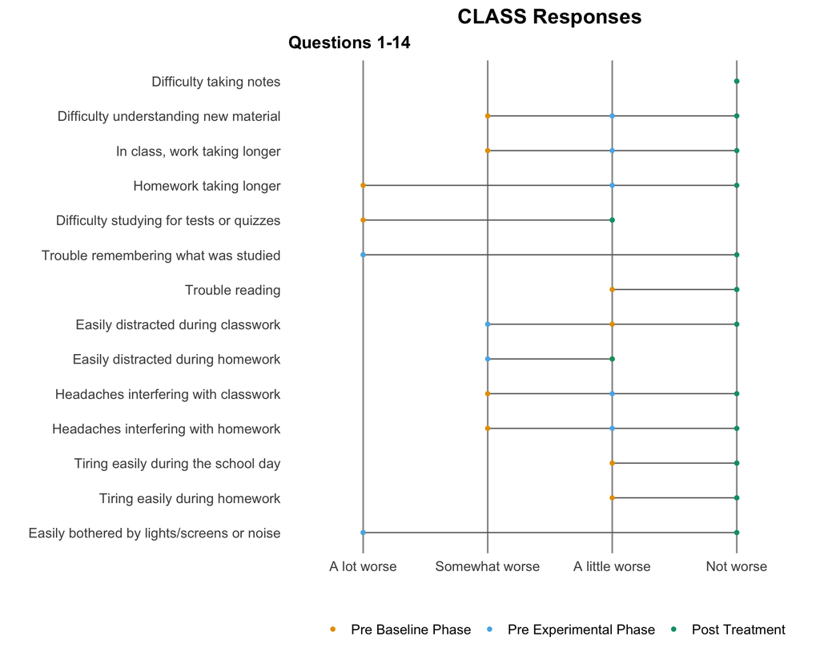

#### CLASS parent 2

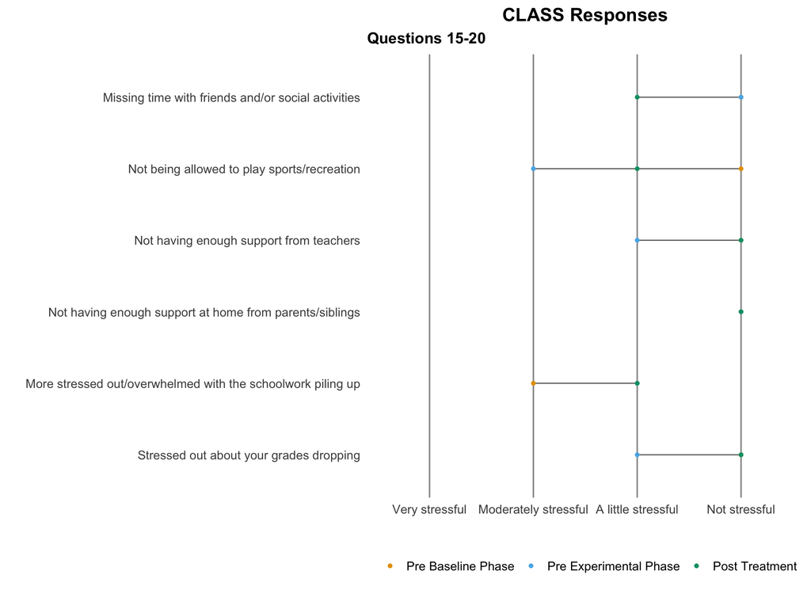

#### CLASS Parent Table

| Question | Pre Baseline Phase | Pre Experimental Phase | Post Treatment |
| --- | --- | --- | --- |
| Difficulty taking notes | Not worse | Not worse | Not worse |
| Difficulty understanding new material | Somewhat worse | A little worse | Not worse |
| In class, work taking longer | Somewhat worse | A little worse | Not worse |
| Homework taking longer | A lot worse | A little worse | Not worse |
| Difficulty studying for tests or quizzes | A lot worse | A little worse | A little worse |
| Trouble remembering what was studied | A lot worse | A lot worse | Not worse |
| Trouble reading | A little worse | Not worse | Not worse |
| Easily distracted during classwork | A little worse | Somewhat worse | Not worse |
| Easily distracted during homework | A little worse | Somewhat worse | A little worse |
| Headaches interfering with classwork | Somewhat worse | A little worse | Not worse |

[output cut: 10 more lines]

### PCSS

Pre-baseline symptom severity levels that guided treatment selection:

- Feeling “slow”
- Feeling “foggy”
- Difficulty concentrating
- Difficulty remembering
- Cognitive symptom cluster

#### All Scores

| Symptom | Pre Baseline Phase | Pre Experimental Phase | Post Treatment |
| --- | --- | --- | --- |
| Headache | 5 | 2 | 3 |
| Nausea | 2 | 0 | 0 |
| Vomiting | 0 | 0 | 0 |
| Balance problems | 4 | 1 | 2 |
| Dizziness | 2 | 1 | 1 |
| Fatigue | 3 | 0 | 2 |
| Trouble falling asleep | 2 | 3 | 1 |
| Excessive sleep | 2 | 0 | 0 |
| Loss of sleep | 2 | 3 | 1 |
| Drowsiness | 5 | 1 | 2 |

[output cut: 19 more lines]

#### Symptom Scores

| Symptom | Pre Baseline Phase | Pre Experimental Phase | Post Treatment |
| --- | --- | --- | --- |
| Headache | 5 | 2 | 3 |
| Nausea | 2 | 0 | 0 |
| Vomiting | 0 | 0 | 0 |
| Balance problems | 4 | 1 | 2 |
| Dizziness | 2 | 1 | 1 |
| Fatigue | 3 | 0 | 2 |
| Trouble falling asleep | 2 | 3 | 1 |
| Excessive sleep | 2 | 0 | 0 |
| Loss of sleep | 2 | 3 | 1 |
| Drowsiness | 5 | 1 | 2 |

[output cut: 12 more lines]

#### Total and Cluster Scores

| Symptom | Pre Baseline Phase | Pre Experimental Phase | Post Treatment |
| --- | --- | --- | --- |
| Total Score | 73 | 27 | 32 |
| Headache-Migraine Cluster | 16 | 7 | 11 |
| Cognitive Cluster | 18 | 8 | 5 |
| Anxiety-Mood Cluster | 16 | 3 | 6 |
| Ocular-Motor Cluster | 1 | 0 | 1 |
| Vestibular Cluster | 8 | 2 | 3 |
| Sleep Cluster | 14 | 7 | 6 |

## Repeated Measurements

### Status Tracking

#### Measurement

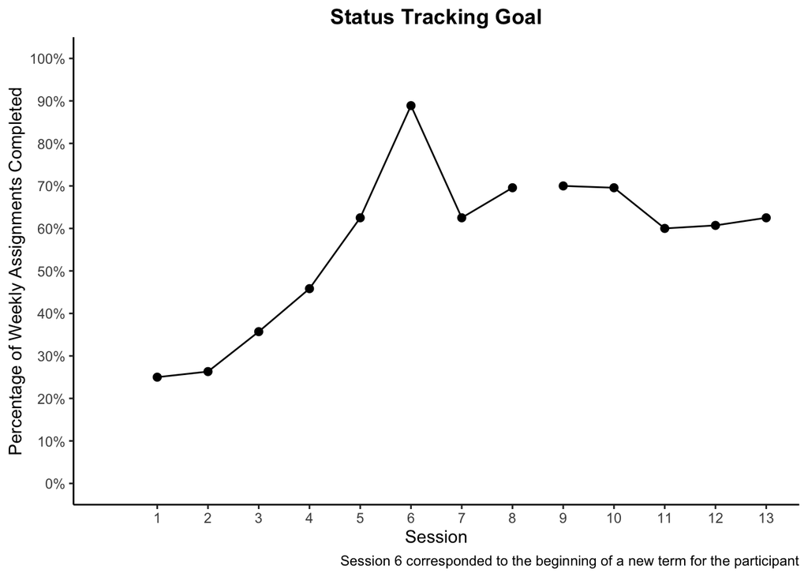

#### Assignment Count

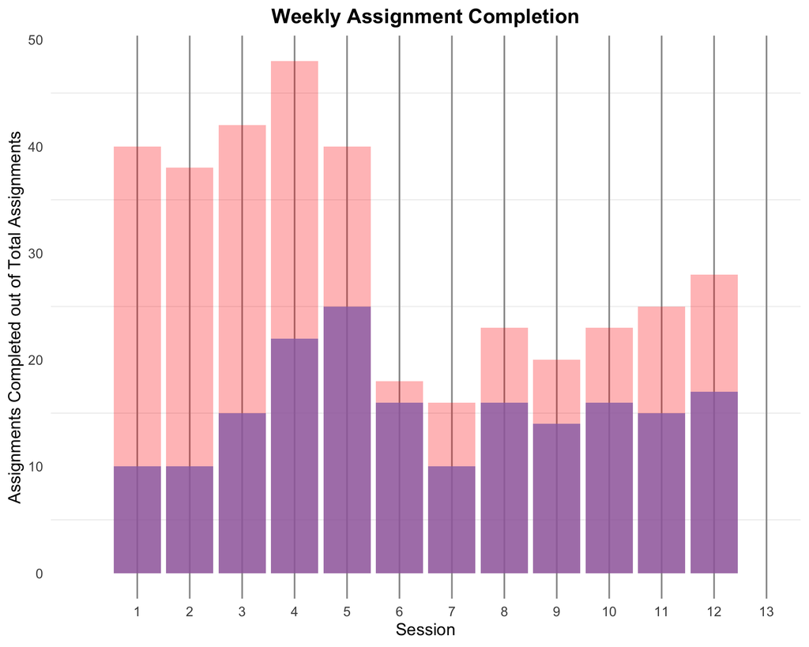

#### Assignment Count 2

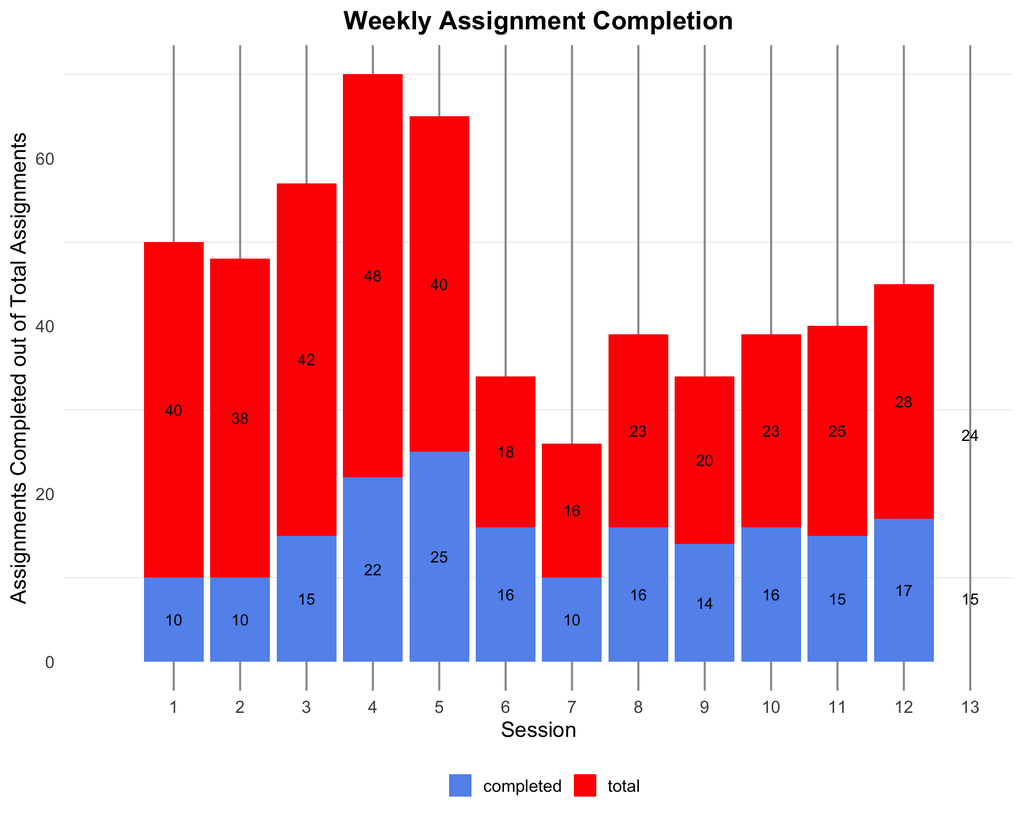

#### Assignment Count Table

| Session | Assignments Completed | Total Assignments | Completion Percentage |
| --- | --- | --- | --- |
| 1 | 10 | 40 | 0.25 |
| 2 | 10 | 38 | 0.263157894736842 |
| 3 | 15 | 42 | 0.357142857142857 |
| 4 | 22 | 48 | 0.458333333333333 |
| 5 | 25 | 40 | 0.625 |
| 6 | 16 | 18 | 0.888888888888889 |
| 7 | 10 | 16 | 0.625 |
| 8 | 16 | 23 | 0.695652173913043 |
| 9 | 14 | 20 | 0.7 |
| 10 | 16 | 23 | 0.695652173913043 |

[output cut: 3 more lines]

### Repeated Strategy Measurements

Cognitive Strategy: Use of academic planner to track weekly assignments.

#### Frequency of Strategy Use (Plot 1)

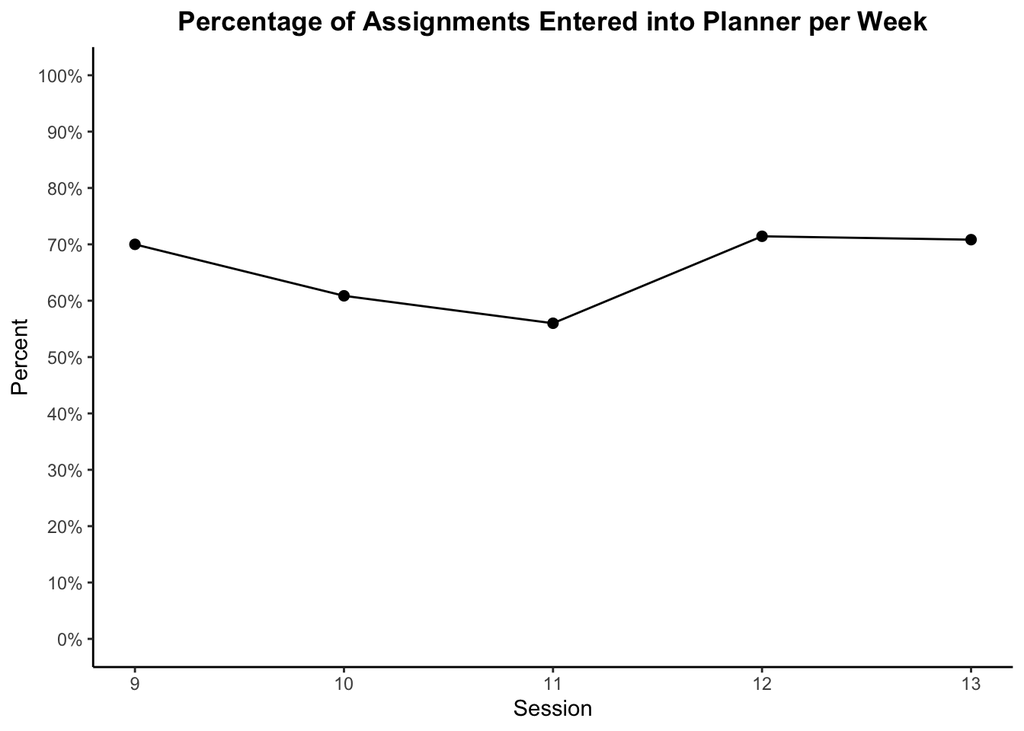

#### Frequency of Strategy Use (Plot 2)

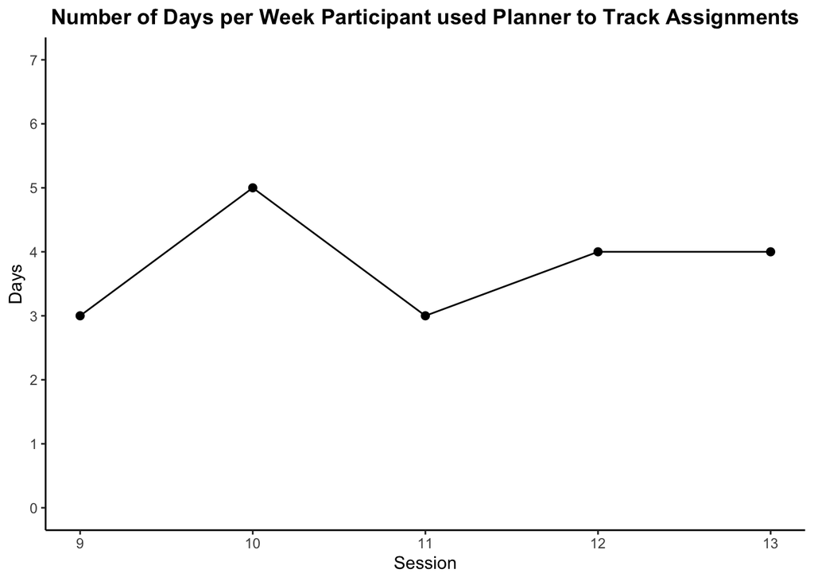

#### Perceived Strategy Helpfulness

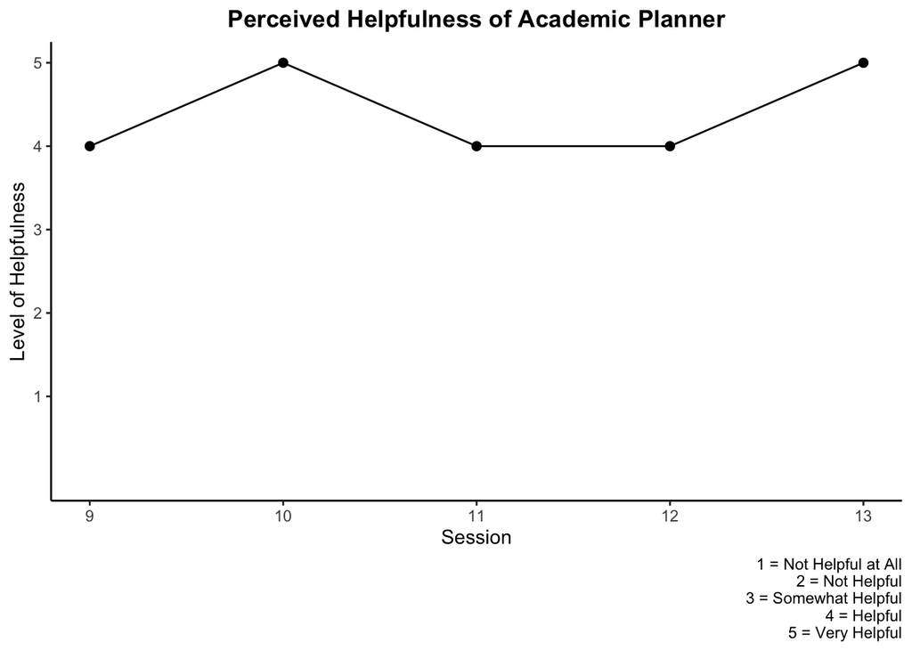

## Treatment Implementation Measurements

### TARF

The TARF is used to measure social validity.

| Question | Response |
| --- | --- |
| The clinician's teaching of the cognitive strategy was effective | Agree |
| I was motivated to use my strategy outside of therapy sessions | Agree |
| The duration of time to learn my cognitive strategy was longer than anticipated | Neutral |
| I am confident I learned my cognitive strategy | Agree |
| Learning a cognitive strategy helped me reach my school and other goals | Agree |
| I liked attending therapy sessions | Neutral |
| I experienced discomfort learning and implementing a cognitive strategy to address my school and other goals | Disagree |
| To what extent do you feel like you understand the concept and importance of cognitive strategy instruction? | NA |
| Anything else you would like to share with us? | NA |